# Using GAN for Generating Hand-written Digit Images

**GAN (Generative Adversarial Network)** [1] is a framework proposed by Ian Goodfellow, Yoshua Bengio and others in 2014.

A GAN can be trained to generate images from random noises. For example, we can train a GAN on MNIST (hand-written digits dataset) to generate digit images that look like hand-written digit images from MNIST, which could be used to train other neural networks.

The code in this notebook is based on the **GAN MNIST example in TensorFlow by Udacity** [2] which uses TensorFlow, but we use Keras on top of TensorFlow for more straightforward construction of networks. Many of the ideas on training are from **How to Train a GAN? Tips and tricks to make GANs work** [4].

## MNIST

MNIST is a well known database of handwritten digits [3].

```python
import numpy as np
import keras
import keras.backend as K
from keras.layers import Input, Dense, Activation, LeakyReLU, BatchNormalization
from keras.models import Sequential
from keras.optimizers import Adam
from sklearn.model_selection import train_test_split
import matplotlib.pyplot as plt
%matplotlib inline
```

The below will download MNIST dataset (if not already).

```python
(X_train, y_train), (X_test, y_test) = keras.datasets.mnist.load_data()
```

Let's examine sample images. We use 'gray' color map since it has no color information.

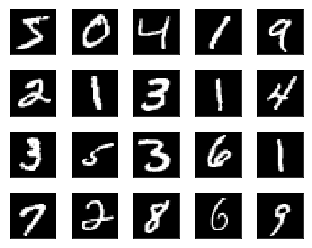

```python
plt.figure(figsize=(5, 4))
for i in range(20):
    plt.subplot(4, 5, i+1)
    plt.imshow(X_train[i], cmap='gray')
    plt.xticks([])
    plt.yticks([])
plt.tight_layout()
plt.show()
```

All MNIST digit images come in 28x28 size.

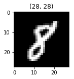

```python
sample = X_train[17]

plt.figure(figsize=(3, 2))
plt.title(sample.shape)
plt.imshow(sample, cmap='gray')
plt.show()
```

The minimum and maximum sizes of MNIST image data is 0 and 255 respectively.

```python
X_train.min(), X_train.max()
```

```
(0, 255)
```

## Generator

We want to build a generator that generates realistic hand-written images.

[figure not shown]

The input to the generator is called 'latent sample' which is a series of randomly generated numbers. We use the normal distribution rather than the uniform distribution as suggested in [4].

```python
def make_latent_samples(n_samples, sample_size):
    #return np.random.uniform(-1, 1, size=(n_samples, sample_size))
    return np.random.normal(loc=0, scale=1, size=(n_samples, sample_size))
```

The sample size is a hyperparameter. Below, we use a vector of 100 randomly generated number as a sample.

```python
make_latent_samples(1, 100) # generates one sample
```

```
array([[ 0.27473292, -0.10655303,  1.09659154, -0.15366093, -0.61587259,
         0.26621725, -0.01077858,  1.90989847, -1.18569009, -0.03249574,
         0.6695888 ,  0.93482157, -1.00884217, -0.29230866, -1.13929507,
        -0.01707456,  0.37335705,  0.33970841,  1.37859658, -0.53026397,
         1.12131043, -1.66056623, -0.01493777,  0.808652  , -0.36080177,
         1.18045669, -0.33343053,  0.60287437,  0.9825658 , -0.31889656,
         0.1179318 , -0.91808507, -1.03957979,  0.40643158, -0.32754068,
         0.80441626, -0.01966988, -0.79409032,  1.55127879,  0.34457065,
        -0.00255198,  1.01100422,  0.56261678, -0.39284342, -0.03217389,
         1.09418122, -0.90881511, -0.19342759,  0.3317994 ,  0.19549762,
        -1.40058816, -0.16028498, -1.86537691,  0.6165322 , -0.4672151 ,
        -0.23835781, -0.35751269, -0.97823372,  1.26912872, -1.29290883,
        -0.97779726,  1.76487061, -0.33914689, -0.57437618,  0.86655979,
        -0.27751868,  0.71869572, -1.22436248,  0.7134086 , -1.1244994 ,
         0.99746905, -0.00786507, -0.66620361, -1.40849483, -0.26476278,
        -0.40399178,  0.35693832, -1.45288997, -0.79326825, -0.48003003,
        -0.15437594,  0.12191884, -0.00680743, -1.30782153,  0.45268918,
         0.68991131,  1.85151145,  1.05853026, -0.4318387 , -0.19847975,
        -1.13489859, -0.59428163,  0.4483107 , -1.07967249, -0.02395855,
         1.00938931,  0.06230197, -1.74878905, -0.13811637, -0.4902213 ]])
```

The generator is a simple fully connected neural network with one hidden layer with the leaky ReLU activation. It takes one latent sample (100 values) and produces 784 (=28x28) data points which represent a digit image.

```python
generator = Sequential([
    Dense(128, input_shape=(100,)),
    LeakyReLU(alpha=0.01),
    Dense(784),
    Activation('tanh')
], name='generator')

generator.summary()
```

```
_________________________________________________________________
Layer (type)                 Output Shape              Param #
=================================================================
dense_1 (Dense)              (None, 128)               12928
_________________________________________________________________
leaky_re_lu_1 (LeakyReLU)    (None, 128)               0
_________________________________________________________________
dense_2 (Dense)              (None, 784)               101136
_________________________________________________________________
activation_1 (Activation)    (None, 784)               0
=================================================================
Total params: 114,064
Trainable params: 114,064
Non-trainable params: 0
_________________________________________________________________
```

The last activation is **tanh**. According to [4], this works the best. It also means that we need to rescale the MNIST images to be between -1 and 1.

Initially, the generator can only produce garbages.

[figure not shown]

As such, the generator needs to learn how to generate realistic hand-written images from the latent sample (randomly generated numbers).

How to train this generator? That is the question tackled by GAN.

Before talking about GAN, we shall discuss the discriminator.

## Discriminator

The discriminator takes a digit image and classifies whether an image is real (1) or not (0).

If the input image is from the MNIST database, the discriminator should classify it as real.

[figure not shown]

If the input image is from the generator, the discriminator should classify it as fake.

[figure not shown]

The discriminator is a simple fully connected neural network with one hidden layer with the leaky ReLU activation.

```python
discriminator = Sequential([
    Dense(128, input_shape=(784,)),
    LeakyReLU(alpha=0.01),
    Dense(1),
    Activation('sigmoid')
], name='discriminator')

discriminator.summary()
```

```
_________________________________________________________________
Layer (type)                 Output Shape              Param #
=================================================================
dense_3 (Dense)              (None, 128)               100480
_________________________________________________________________
leaky_re_lu_2 (LeakyReLU)    (None, 128)               0
_________________________________________________________________
dense_4 (Dense)              (None, 1)                 129
_________________________________________________________________
activation_2 (Activation)    (None, 1)                 0
=================================================================
Total params: 100,609
Trainable params: 100,609
Non-trainable params: 0
_________________________________________________________________
```

The last activation is **sigmoid** to tell us the probability of whether the input image is real or not.

We train the discriminator using both the MNIST images and the images generated by the generator.